# ESAME FONDAMENTI DI SCIENZA DEI DATI E LABORATORIO

## Analisi del numero di sparatorie della polizia statunitense

Molte persone affermano che la polizia degli Stati Uniti è razzista e il loro atteggiamento differisce in base alla razza del colpevole che stanno affrontando.

Lo scopo di questa analisi è capire il fattore,quindi la variabile tra quelle proposte nel dataset, che influenza un poliziotto a sparare.

## Per iniziare

Importiamo il dataset e cerchiamo di avere una conoscenza di base dei dati.

Il dataset contiene informazioni sulle persone come il loro nome, età, sesso e razza. Insieme ad esse, vi sono informazioni sulle sparatorie in cui sono coinvolti, come la data dell’evento, dove è successo, come sono stati uccisi, se hanno mostrato qualche malattia mentale e altre variabili che vedremo.

## GRAFICO DELLE SPARATORIE ANNUALI

Nel prossimo grafico mostreremo com’è cambiato il numero delle sparatorie tra il 2015 e il 2020.

Fino al 2019 l’andamento del numero delle sparatorie è stato similare, per poi diminuire drasticamente nel 2020. Ciò può essere dovuto (a parer mio) alla morte di George Floyd.

L’accaduto ha attirato un’enorme attenzione nei mass media e probabilmente ha portato i poliziotti ad avere un comportamento meno violento

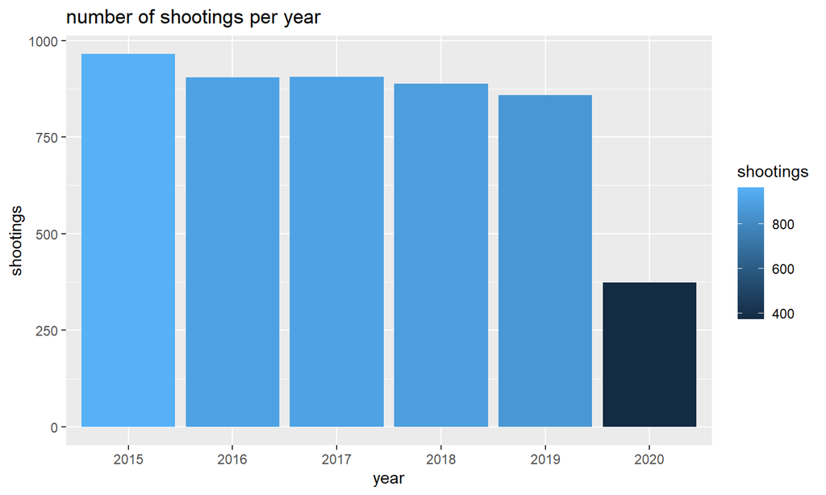

## NUMERO MEDIO DI SPARATORIE OGNI MESE

Successivamente ho analizzato con più precisione il numero di sparatorie mese per mese mostrando la media (~75) che confrontandolo con il numero di giorni è un numero abbastanza alto (~2.5)

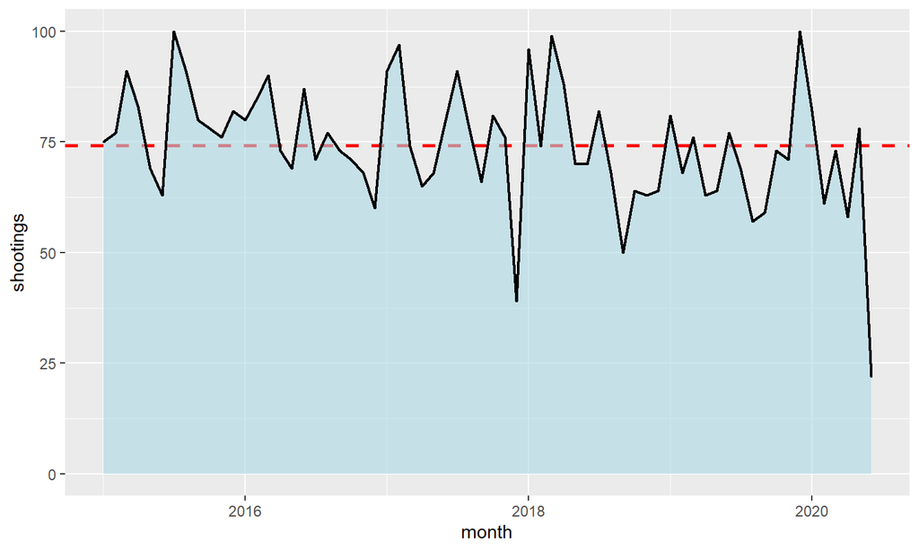

## UOMINI O DONNE?

Il seguente grafico,invece, mostra la prevalenza di uomini rispetto le donne sul numero di persone sparate.

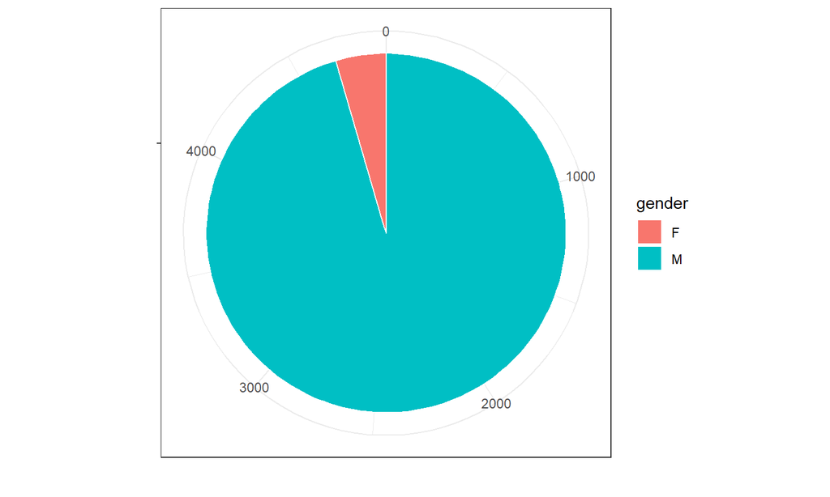

## ADULTI,RAGAZZI O ANZIANI?

Parlando dell’età,dividiamo le persone in 3 categorie:

- adulti
- ragazzi
- anziani

Il numero degli adulti è molto maggiore rispetto le altre due categorie,ma vediamo in dettaglio il range di età più coinvolto.

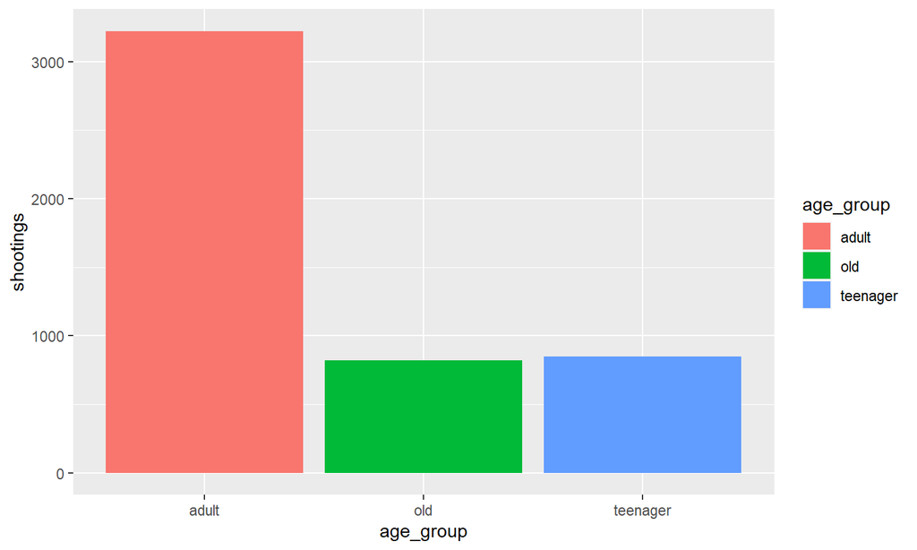

## L’ETA’ DELLE VITTIME

Analizzando la questione per ogni età,si puo notare che la maggior parte delle “vittime” ha un età compresa tra i 25 e i 40 anni sia per le donne che per gli uomini.

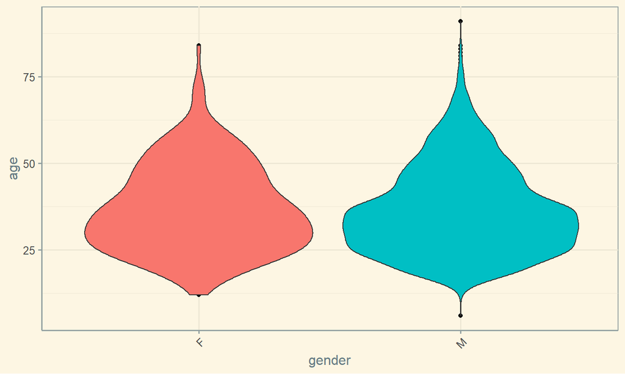

## CHI E’ PIU’ GIOVANE?

La frequenza più alta si trova tra i 25 e i 40 anni,come abbiamo dimostrato precedentemente. Ma sulla base del grafico della densità, si può notare che i neri a cui è stato sparato sono più giovani di altre razze.

Tesi confermata anche dal secondo grafico(boxplot). Ciò potrebbe indicare che queste persone entrano a contatto con il crimine prima rispetto le altre, oppure nel caso dell’abuso di potere, diventano vittime più presto.

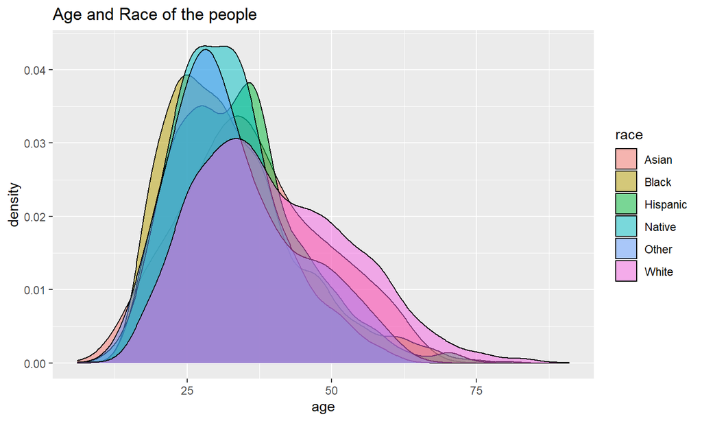

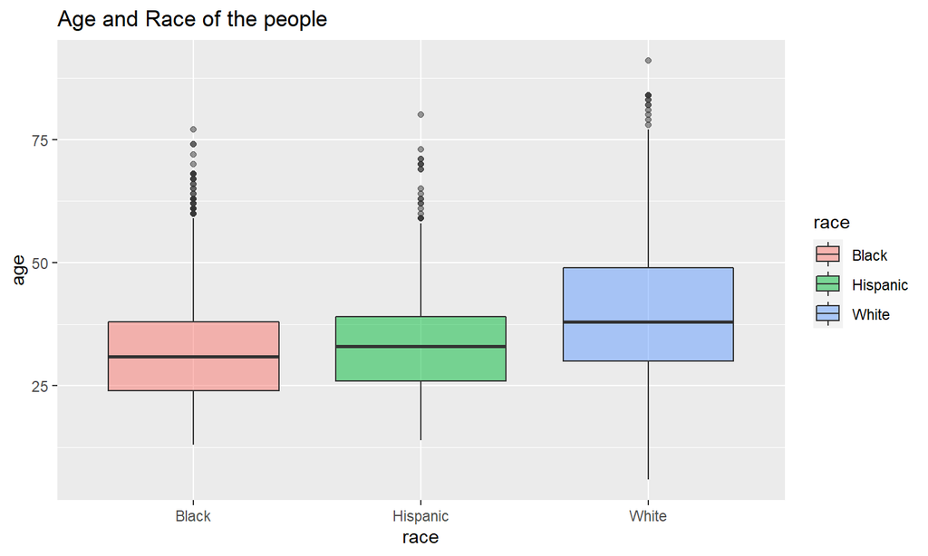

## ANALISI DELLE VARIABILI

Ora passeremo a studiare le varie relazioni tra le variabili, in particolare confrontandole con il numero di sparatorie, per capire ciò che può influenzare la scelta di un poliziotto.

## LA “RAZZA” INFLUENZA IL POLIZIOTTO?

La prima analisi è stata fatta appunto sulla razza, quindi su un possibile razzismo da parte della polizia.

Come mostra il grafico non sembra esserci alcuna relazione tra numero di sparatorie e la “razza” delle persone, in quanto il numero di Bianchi uccisi è superiore a tutti gli altri (Neri compresi).

Tuttavia bisogna tenere conto che il [numero](https://www.census.gov/quickfacts/fact/table/US/PST045219) di persone di discendenza africana in America è molto inferiore (circa il 13%) rispetto al numero di persone di discendenza europea( 76%)

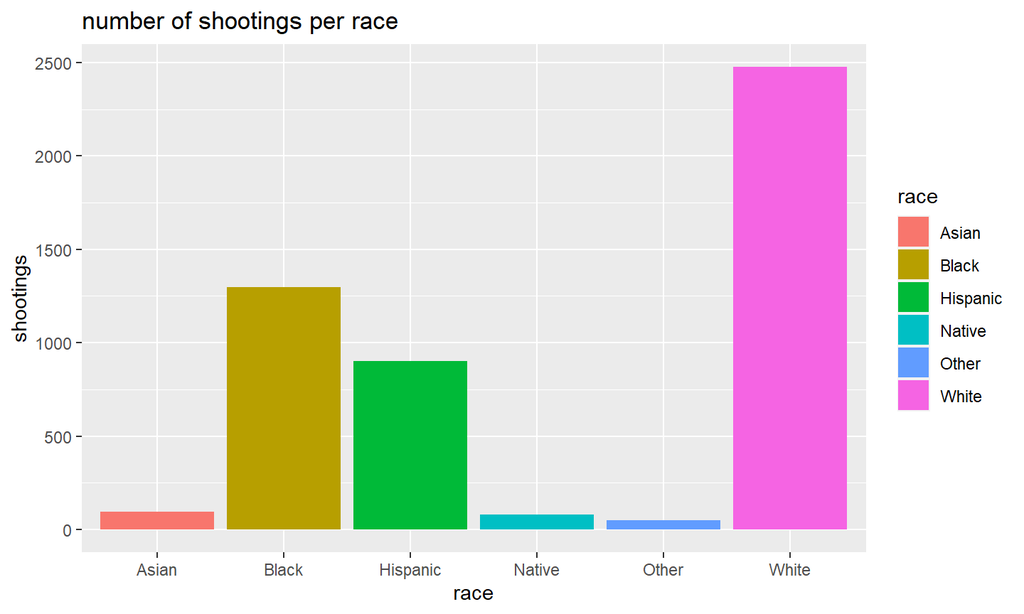

## REAZIONE DURANTE IL CONFRONTO

Il dataset ci mostra come ogni persona può avere diversi comportamenti non appena nota la presenza del poliziotto: chi scappa a piedi,chi in macchina, e chi non scappa.

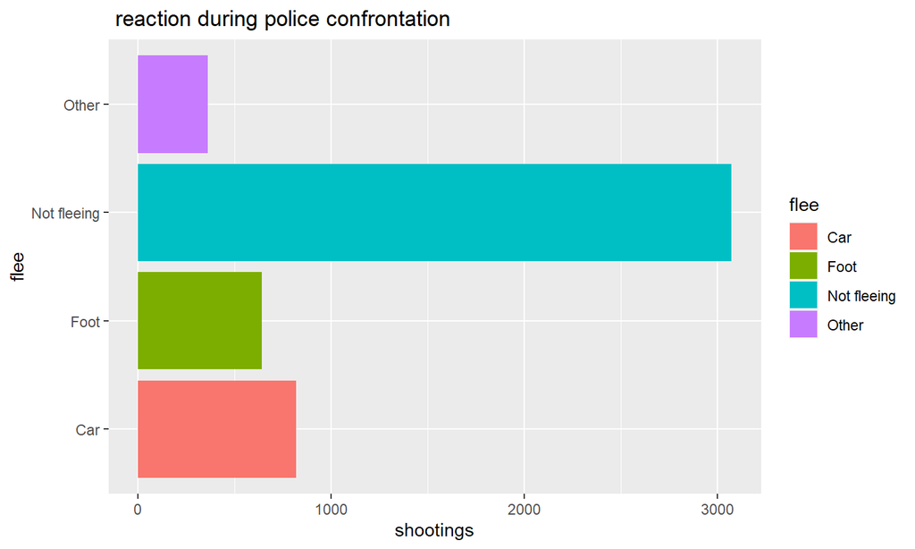

## COMMENTO

Il grafico sembra mostrarci le persone che non sono scappate sono anche quelle sparate più frequentemente.  
Perchè si dovrebbe sparare a qualcuno che non sta scappando? E’ realmente questa la motivazione che influenza il poliziotto?

Troviamo la risposta a questa domanda nell’analisi del livello di pericolosità della persona e di come si comporta in quella situazione.

## LIVELLO DI PERICOLOSITA’

Il livello di pericolosità è una variabile più ragionevole da analizzare. La maggior parte delle vittime ha avuto un atteggiamento aggressivo e a rigor di logica questo può aver portato la polizia alla decisione di sparare.

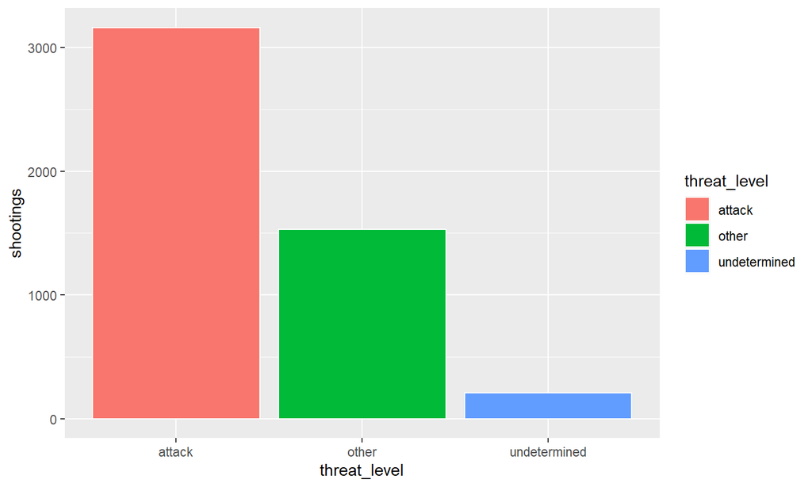

## POSSEDIMENTO DI ARMA

Continuiamo ad analizzare le variabili e passiamo all’analisi dell’arma posseduta dalle persone in quel momento.

## COSA SI POSSIEDE?

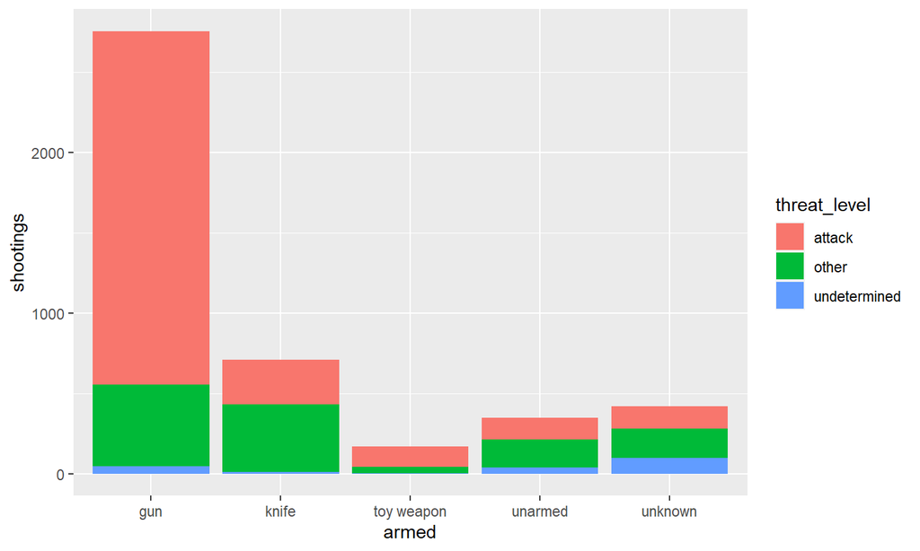

## ARMA POSSEDUTA

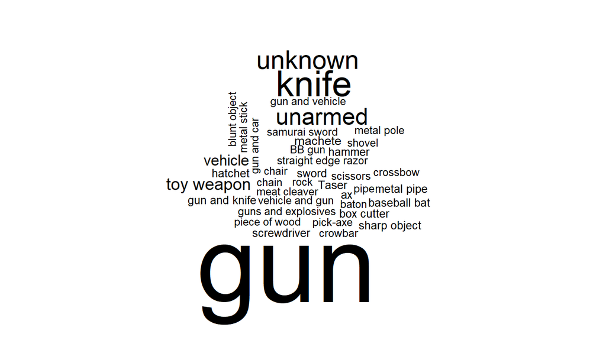

## COMMENTO

Innanzitutto notiamo come il possesso di un arma da fuoco influenzi il poliziotto a sparare probabilmente per proteggere la sua incolumità, ciò a supporto dell’analisi precedentemente fatta. Alla maggior parte delle sparatorie partecipano persone che hanno un attegiamento aggressivo e in possesso di arma.

La prossima variabile che ho voluto tenere in considerazione è lo stato mentale delle persone.

## SEGNI DI MALATTIA MENTALE

La mia ipotesi è stata subito confutata dai dati,in quanto non vi è alcuna relazione tra “stato mentale” e numero di sparatorie. E’ facile cadere nel falso equivoco e nell’errata echitettatura di tutti i criminali come “persone con malattie mentali”.

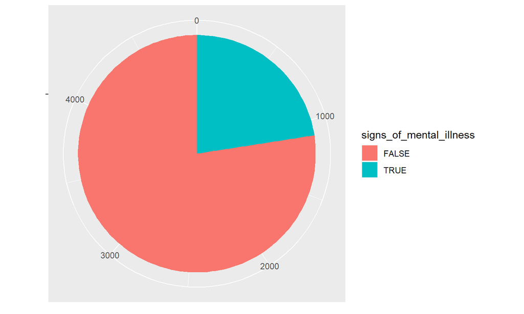

## QUALE RAZZA E’ “MENO IN REGOLA”?

Un’altra analisi interessante al di fuori di cosa influenza un poliziotto è il possedimento di armi da parte dei minori e quindi di chi non potrebbe averla. A supporto dell’analisi sull’età media,le persone di discendenza africana potrebbero essere state coinvolte prima nella criminalità.

```
## [1] 32
```

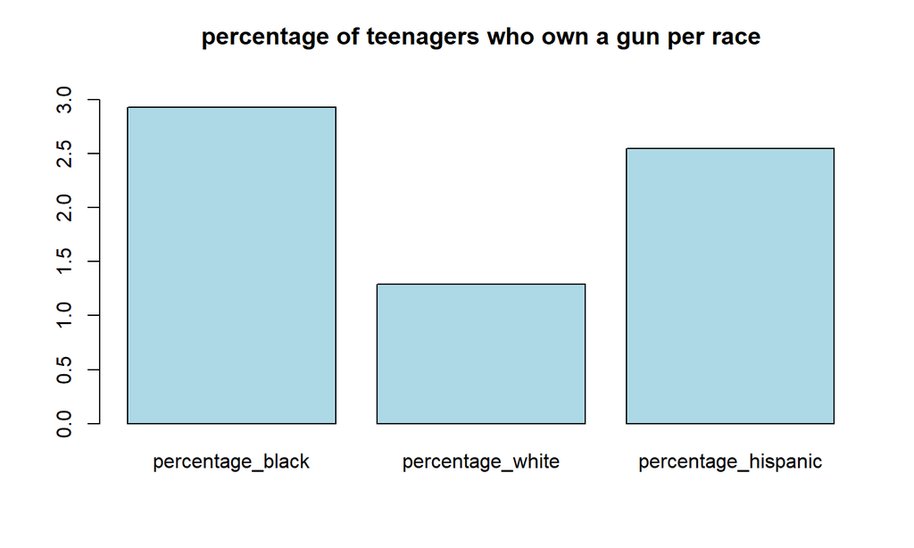

## DOVE ACCADONO LE SPARATORIE?

Passando agli stati dove le sparatorie avvengono più frequentemente, secondo la mappa, la California ha il numero maggiore,seguita da Texas e Florida

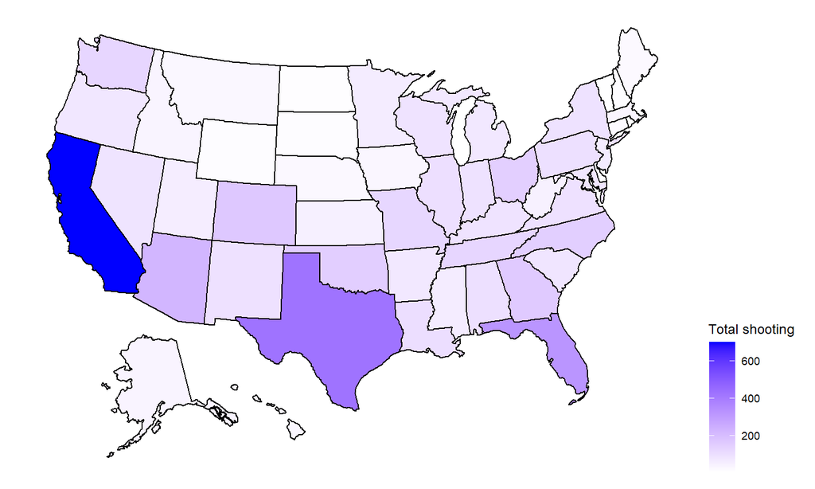

## GRAFICO PER OGNI CITTA’

Entrando più nel dettaglio,vediamo quale Città è più soggetta a questo fenomeno.

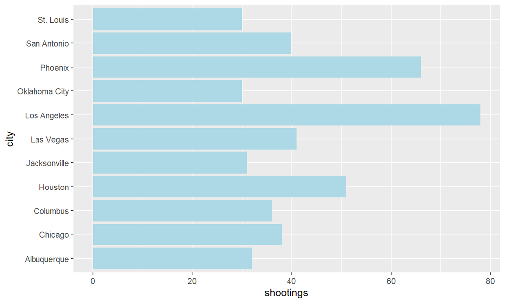

## COMMENTO

Strano non vedere città importanti come New York e Filadelfia.

Questo ci fa capire che la dimensione della città non è un fattore “determinante” in quanto (secondo me) è meno importante rispetto al livello di disoccupazione, che può portare ad un indice di criminalità maggiore.

## CONCLUSIONI

Possiamo affermare che:

## TEMA RAZZISMO

La questione riguarda la differenza di [ceto sociale](https://www.altreinfo.org/riflessioni/11988/criminalita-e-propensione-al-crimine-in-base-alla-razza-di-appartenenza-philippe-rushton/)

Il reddito annuo delle famiglie afro-americane è il più basso, tale differenza comporta un tasso di criminalità più alto, nel 50% degli arresti (io ho analizzato le sparatorie) è incluso un uomo afro-americano.

C’è un razzismo? Si,ma è alimentato da un dislivello sociale.